# 1: Computational Verification

ADF Clarke and AE Hughes

# 1 Setup and Data Import

```r
# set ggplot2 theme
theme_set(ggthemes::theme_tufte())

# use parallel cores for mcmc chains!
options(mc.cores = 4)

# reduce the number of decimal places
options(digits = 3)

# functions used for our Bayesian re-analysis
source("../scripts/our_functions.R")

# set seed to make sure everything is reproducible
set.seed(100320021)
```

We will import data from all experiments. While we’re at it, we will remove error trials.

```r
source("import_and_tidy.R")
summary(d)
```

```
##       p_id            trial        t_id            N_T        d_feature
##  1b-9   :   720   Min.   :  1   left :70935   Min.   : 0.0   Length:142077
##  1b-15  :   720   1st Qu.:160   right:71142   1st Qu.: 1.0   Class :character
##  2a-13  :   720   Median :320                 Median : 4.0   Mode  :character
##  2b-19  :   720   Mean   :321                 Mean   :10.7
##  2c-19  :   720   3rd Qu.:481                 3rd Qu.:19.0
##  4b-20  :   720   Max.   :640                 Max.   :31.0
##  (Other):137757
##        rt          response         error      exp_id
##  Min.   :   0   Min.   :0.000   Min.   :0   Length:142077
##  1st Qu.: 446   1st Qu.:0.000   1st Qu.:0   Class :character
##  Median : 526   Median :1.000   Median :0   Mode  :character
##  Mean   : 587   Mean   :0.501   Mean   :0
##  3rd Qu.: 645   3rd Qu.:1.000   3rd Qu.:0
##  Max.   :4989   Max.   :1.000   Max.   :0
##
##      ring
##  Length:142077
##  Class :character
##  Mode  :character
##
##
##
##
```

# 2 Freqentist Computational Replication of Buetti et al (2019)

Before doing anything else (i.e., new), we want to confirm that we can replicate the original analysis. This section walks through the original analysis.

```r
# functions used for the analysis re-implementation
source("../scripts/reimplementation.R")
```

## 2.1 Calculating $D$

Calculate $D_e$ (the empirical slopes) for each condition in each experiment.

```r
De <- map_dfr(unique(d$exp_id), calc_D_per_feature) %>%
  mutate(exp_id = as_factor(exp_id),
    d_feature = as_factor(d_feature),
         d_feature = fct_relevel(d_feature, "yellow", "orange", "blue", "triangle", "semicircle", "diamond", "circle")) %>%
  arrange(exp_id, d_feature)
```

```r
De %>% filter(exp_id %in% c("1a", "3a")) %>%
  knitr::kable(digits = 1) %>% kableExtra::kable_styling()
```

| exp_id | d_feature | D |
| --- | --- | --- |
| 1a | yellow | 16.0 |
| 1a | orange | 9.8 |
| 1a | blue | 76.8 |
| 3a | yellow | 22.4 |
| 3a | orange | 51.0 |
| 3a | blue | 15.5 |

```r
De %>% filter(exp_id %in% c("1b", "3b")) %>%
  knitr::kable(digits = 1) %>% kableExtra::kable_styling()
```

| exp_id | d_feature | D |
| --- | --- | --- |
| 1b | triangle | 141.1 |
| 1b | diamond | 77.2 |
| 1b | circle | 62.1 |
| 3b | semicircle | 152.7 |
| 3b | diamond | 59.3 |
| 3b | circle | 23.7 |

```r
De <- De %>%
  mutate(d_feature = fct_relevel(d_feature, "orange diamond", "orange circle", "blue diamond", "blue circle", "yellow diamond", "yellow circle", "yellow triangle",
                                 "blue triangle", "orange triangle", "yellow semicircle", "blue semicircle", "orange semicircle")) %>%
  arrange(exp_id, d_feature)

De %>% filter(exp_id %in% c("2a", "2b", "2c", "4a", "4b", "4c")) %>%
  knitr::kable(digits = 1) %>% kableExtra::kable_styling()
```

| exp_id | d_feature | D |
| --- | --- | --- |
| 2a | orange diamond | 6.9 |
| 2a | blue circle | 31.2 |
| 2a | yellow triangle | 8.6 |
| 2b | orange circle | 6.8 |
| 2b | yellow diamond | 11.7 |
| 2b | blue triangle | 55.7 |
| 2c | blue diamond | 44.3 |
| 2c | yellow circle | 15.9 |
| 2c | orange triangle | 16.7 |
| 4a | orange diamond | 21.4 |
| 4a | blue circle | 4.2 |
| 4a | yellow semicircle | 18.3 |
| 4b | orange circle | 15.0 |
| 4b | yellow diamond | 12.5 |
| 4b | blue semicircle | 16.5 |
| 4c | blue diamond | 12.8 |
| 4c | yellow circle | 11.0 |
| 4c | orange semicircle | 34.2 |

## 2.2 Predicting $D$

We can now use the values of $D$ calculated above to predict values of $D$ ($D_p$) for all experiments 2x and 4x (referred to as $D_{c,s}$ in the main manuscript).

```r
exps_to_predict <- c("2a", "2b", "2c", "4a", "4b", "4c")
Dp <- map_df(exps_to_predict, gen_exp_predictions, De)
```

Recreate the scatter plots from Buetti et al (2019), Figure 4.

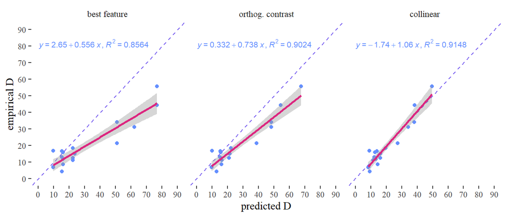

Figure 2.1: Computational replication of Figure 4 (top row) from Buetti et al (2019).

```r
left_join(Dp, De, by = c("exp_id", "d_feature")) %>%
  pivot_longer(
    cols = c(`best feature`, `orthog. contrast`, collinear),
    values_to = "Dp",
    names_to = "method") %>%
  mutate(method = fct_relevel(method, "best feature", "orthog. contrast")) %>%
  ggplot(aes(x = Dp, y = D, colour = method)) +
  geom_point(color = "#648FFF") +
  geom_abline(linetype = 2, colour = "#785EF0") +
  geom_smooth(method = "lm", formula = y ~ x, colour = "#DC267F") +
    stat_poly_eq(formula = y ~ x,
               aes(label = paste(..eq.label.., ..rr.label.., sep = "*plain(\",\")~")),
               parse = TRUE, size = 2.8, label.y = 0.9, coef.digits = 3, rr.digits = 4) +
  facet_wrap(~ method) +
  scale_x_continuous("predicted D", limits = c(0, 90), breaks = seq(0, 90, 10)) +
  scale_y_continuous("empirical D", limits = c(0, 90), breaks = seq(0, 90, 10)) +
  scale_colour_manual(values = c("#648FFF", "#648FFF", "#648FFF"))
```

Now put mean absolute error in a table:

```r
left_join(Dp, De, by = c("exp_id", "d_feature")) %>%
  pivot_longer(
    cols = c(`best feature`, `orthog. contrast`, collinear),
    values_to = "Dp",
    names_to = "method") %>%
  mutate(method = fct_relevel(method, "best feature", "orthog. contrast"),
         error = D-Dp) %>%
  group_by(method) %>%
  summarise(mean_err = mean(abs(error))) %>%
  knitr::kable()
```

| method | mean_err |
| --- | --- |
| best feature | 11.37 |
| orthog. contrast | 7.27 |
| collinear | 3.41 |

Now we compute $R^2$ to get a measure of how well $D_p$ predict the $D_e$, calculated for each method and each set of experiments, as well as an overall measure.

```r
Dp_tmp <- left_join(Dp, De, by = c("exp_id", "d_feature")) %>%
  pivot_longer(-c(exp_id, d_feature, D, iter), names_to = "method", values_to = "Dp")

df_r2 <- tibble(exp_id = as.character(), method = as.character(), r2 = as.numeric())

for (e_id in exps_to_predict) {
  for (meth in unique(Dp_tmp$method)) {

    df <- filter(Dp_tmp, method == meth, exp_id == e_id)
    r2 <- summary(lm(D ~ Dp, data = df))$r.squared

    df_r2 <- add_row(df_r2,
                      exp_id = paste("Exp", e_id), method = meth, r2 = r2)
  }
}

 for (meth in unique(Dp_tmp$method)) {
  df <- filter(Dp_tmp, method == meth)
  r2 <- summary(lm(D ~ Dp, data = df))$r.squared
  # print(meth)
  # print(summary(lm(D ~ Dp, data = df))$r.squared)
  df_r2 <- add_row(df_r2,
                 exp_id = "all", method = meth, r2 = r2)
 }

df_r2 %>% pivot_wider(method, names_from = "exp_id", values_from = "r2") %>%
  knitr::kable(digits = 4) %>% kableExtra::kable_styling()
```

| method | Exp 2a | Exp 2b | Exp 2c | Exp 4a | Exp 4b | Exp 4c | all |
| --- | --- | --- | --- | --- | --- | --- | --- |
| best feature | 0.998 | 1 | 0.988 | 0.593 | 0.478 | 0.936 | 0.856 |
| orthog. contrast | 0.993 | 1 | 0.980 | 0.757 | 0.546 | 0.989 | 0.902 |
| collinear | 0.979 | 1 | 0.982 | 0.923 | 0.658 | 0.998 | 0.915 |

```r
rm(df_r2, Dp_tmp)
```

The values in the *all* column match those given in Figure 4 (top) (Buetti et al, 2019).